# Stochastic modelling

## Introduction

Stock Price Modelling is a very well celebrated as well as challenging job for the people in industry as well as in academics. There are several approaches. In this paper we will implement stochastic modelling based on mainly a dataset of `Bank NIFTY` starting from 1st Jan,2020 and in each interval of 1 min. We have 5000 observations there. For the entire study, we will try to model `Open Price` throughout.

## Data

Lets take a look over the data,

```r
data=read.csv("E:\\pdf\\Quant Fin\\BankniftyFut.csv",nrows = 5000)
data$DATE=as.Date(data$DATE,"%d-%m-%Y")
data$TIME=as.POSIXct(data$TIME,format="%H:%M:%S")
str(data)
```

```
## 'data.frame':    5000 obs. of  8 variables:
##  $ DATE  : Date, format: "2020-01-01" "2020-01-01" ...
##  $ TIME  : POSIXct, format: "2025-04-07 09:15:00" "2025-04-07 09:16:00" ...
##  $ OPEN  : num  32417 32457 32446 32445 32461 ...
##  $ HIGH  : num  32465 32466 32452 32464 32474 ...
##  $ LOW   : num  32354 32445 32445 32435 32457 ...
##  $ CLOSE : num  32456 32445 32445 32464 32465 ...
##  $ VOLUME: int  36240 18780 14900 18120 11540 9640 8480 8140 4840 10680 ...
##  $ OI    : int  1304980 1304980 1316960 1316960 1316960 1328860 1328860 1328860 1337200 1337200 ...
```

The scatter plot of the data ,

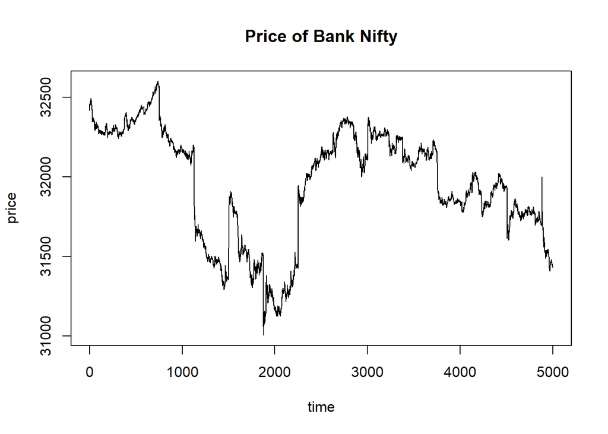

```r
plot(data$OPEN,main="Price of Bank Nifty",xlab="time",
     ylab="price",type = "l")
```

## Modelling

### **Geometric Brownian Motion:**

The SDE is,

$dS_t=\mu S_tdt+\sigma S_tdW_t$ , where $W_t ~$ ~Weiner Process.

#### **Diagnostic**:

Now our stock data to fit the GBM, we must have $logS_t-logS_{t-1}$ follows normal distribution. We will diagnos it graphically using Histogram.

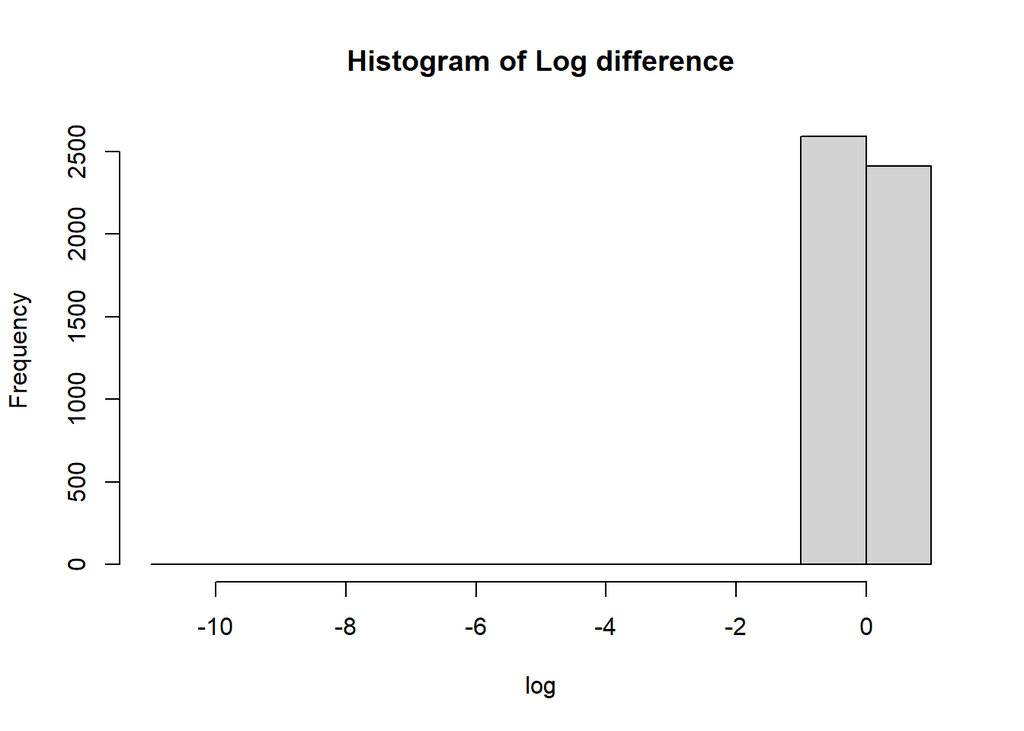

```r
        ratio=rep(0,times=dim(data)[1])
        ratio[1]=data$OPEN[1]
        for (i in 2:dim(data)[1]){
          ratio[i]=data$OPEN[i]/data$OPEN[1]
        }
        data$ratio=ratio
        log=diff(log(data$ratio),lag=1)

        hist(log,main = "Histogram of Log difference")
```

From Histogram it is evident that the data is not coming from a Normal population . Still we fit a GBM to see how it work.

#### **Model fitting:**

##### **Method of Moment estimates:**

Here we estimated the parametres of GBM using MOM estimates. We found,

Parametre

| Parametre | Value |
| --- | --- |
| $$\mu$$ | -0.00208 |
| $$\sigma$$ | 0.1468849 |

##### **Fit:**

[figure not shown]

```r
ratio=rep(0,times=dim(data)[1])
ratio[1]=data$OPEN[1]
ratio[1]=data$OPEN[1]
for (i in 2:dim(data)[1]){
  ratio[i]=data$OPEN[i]/data$OPEN[1]
}
data$ratio=ratio
log=diff(log(data$ratio),lag=1)
mu_mom=mean(log)
sigma_mom=sd(log)


dt=1/dim(data)[1]
predict_m=function(n=10,mu,sigma){
res=NULL
for (j in 1:n){
predi_mom=rep(0,times=dim(data)[1])
predi_mom[1]=data$OPEN[1]
for(i in 2:dim(data)[1]){
a=predi_mom[i-1]*(mu*dt+sigma*sqrt(dt)*rnorm(1))
predi_mom[i]=predi_mom[i-1]+a
}
res=cbind(res,predi_mom)
}
return(res)
}

matplot(predict_m(5,mu=mu_mom,sigma =sigma_mom),type="l",main="5 Simulated paths of GBM and the original data",ylab="price")
lines(data$OPEN,col="red",type="l",lwd=2)
legend("topleft",legend = c("Original","Simulated"),lwd=c(2,1))
```

##### **Goodness of fit test:**

Here we are calculating the Chi- Square statistic based on a simulated path.

```r
chi=sum((predict_m(1,mu=mu_mom,sigma =sigma_mom)-data$OPEN)**2/data$OPEN)

df <- length(data$OPEN) - 1
p_value <- 1 - pchisq(chi, df)
cat("P-Value: ",p_value)
```

```
## P-Value:  0
```

Here the p-value for the test is coming as 0. That means the data is not fitting well in this case.

##### **Maximum Likelihood Estimates:**

Similarly as above but using MLE estimates of the GBM we fit it with our data. The estimates are,

Parametre

[output not shown]

##### **Fit:**

[figure not shown]

```r
mu_mle=-0.002083886
sigma_mle=0.14687
matplot(predict_m(5,mu=mu_mle,sigma =sigma_mle),type="l",main="5 Simulated paths of GBM and the original data",ylab="price")
lines(data$OPEN,col="red",type="l",lwd=2)
legend("topright",legend = c("Original","Simulated"),lwd=c(2,1))
```

#### Comaparison between two methods of estimation

##### **Goodness of fit** **:**

Similarly as above,

```r
chi=sum((predict_m(1,mu=mu_mom,sigma =sigma_mom)-data$OPEN)**2/data$OPEN)

df <- length(data$OPEN) - 1
p_value <- 1 - pchisq(chi, df)
cat("P-Value: ",p_value)
```

```
## P-Value:  0
```

### **Jump Diffusion Model:**

From the plot of the data , we can see that there is several jumps in the data. So for modelling this kind of data, Jump Diffusion Model is very famous in literature.

Here the SDE is,

$$dS_t=\mu S_tdt+\sigma S_tdW_t+JS_tdN_t$$
, where $N_t$~ Poisson process with parametre $\lambda$ and $J$ represents the jump size. Here we are modelling that, $J$ follows logNormal($\mu_J,\sigma_j$)

###### **Fit:**

The fitting process involves three steps,

1. Fix a threshold, in practice 3- $\sigma$ limits are taken.
2. Value of the price greater than the threshold are used to estimate the parametres for $J$ and $N_t$ . But we did’nt get reasonable output there. So we fine tune it to work better.
3. Value of the price lesser than the threshold are used to estimate the other parametres. Here also we took the same approach .

[figure not shown]

```r
#-------parametre estimation
dt=1/dim(data)[1]
threshold <- 3 * sd(log)     # Define threshold
normal_returns <- log[abs(log) < threshold]
mu_hat <- mean(normal_returns)
sigma_hat <- 0.05


# Step 2: Estimate lambda, mu_J, and sigma_J for jump component
jump_returns <- log[abs(log) >= threshold]
lambda_hat <- 2
  mu_j_hat <- mean(jump_returns)
sigma_j_hat <- 2



#---------model fitting

jump=function(n=10){
res=NULL
for(i in 1:n){
S <- numeric(length(data$OPEN))
S[1] <- data$OPEN[1]

# Simulate the process
for (t in 2:length(S)) {
  # GBM component
  dWt <- rnorm(1, mean = 0, sd = sqrt(dt))
  dS_gbm <- (mu_hat * dt + sigma_hat * dWt) * S[t-1]

  # Jump component
  Nt <- rpois(1, lambda_hat * dt)  # Number of jumps at this step
  if (Nt > 0) {
    J <- rnorm(1, mean = mu_j_hat, sd = sigma_j_hat)  # Jump size
    dS_jump <- (exp(J)) * S[t-1]  # Apply jump multiplicatively
  } else {
    dS_jump <- 0
  }

  # Update stock price
  S[t] <- S[t-1] + dS_gbm + dS_jump
}
res=cbind(res,S)
}
return(res)
}



set.seed(4000000)
plot(data$OPEN,type = "l",lwd=2,main="5 Simulated paths of GBM and the original data",ylab="price")
matplot(jump(5),type = "l",add=TRUE)
legend("topright",legend = c("Original","Simulated"),lwd=c(2,1))
```

```r
chi=sum((predict_m(1,mu=mu_mom,sigma =sigma_mom)-data$OPEN)**2/data$OPEN)

df <- length(data$OPEN) - 1
p_value <- 1 - pchisq(chi, df)
cat("P-Value: ",p_value)
```

```
## P-Value:  0
```

## **Clustering:**

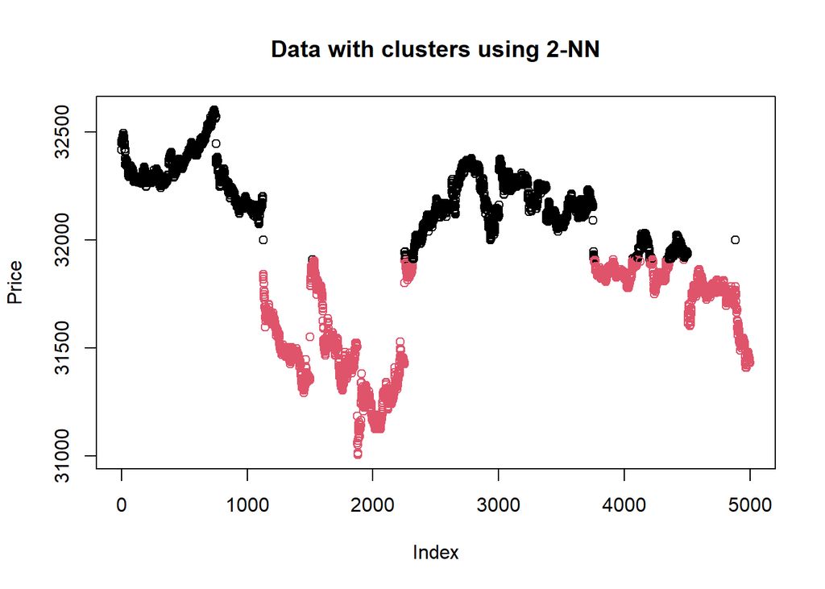

```r
a=kmeans(data$OPEN,2)
plot(data$OPEN,col=a$cluster,main = "Data with clusters using 2-NN",
     ylab="Price")
```

## **Comments on fit:**

We saw that both the model fails to give satisfactory fit to our data. Now we will discuss about the two methods seperately.

### **GBM:**

GBM usually simulate data to be increasing manner. So its highly unlikely for real world data to get fitted well. But if the time interval is very small or the time gap between two observation is fairly large , then it can be assumed that there is not such jumps in that case. So we can assume that in that case GBM may be a good fit to the data. Actually, for stable market GBM works well. Here our log return was far from normality and also we had some jumps in the data, so the GBM approach failed.

### **Jump Diffusion Model :**

In literature , Jump Diffusion Model and its extensions are widely used for modelling the data with jumps. But here we are using the basic model. It is capturing the jump but due to high variability it is not efficient.

## Acknowledgement

I would like to express my sincere gratitude to Professor Abhik Ghosh and Sourojyoti Ghosh for their invaluable guidance and support throughout this work. Their insights and expertise in finance and modelling greatly enhanced my understanding and helped shape this assignment. I am also grateful to my friends for their encouragement and unwavering support.

## Reference

1. Hull, J. C. (2021). Options, Futures, and Other Derivatives (10th ed.). Pearson.
2. Merton, R. C. (1976). Option Pricing When Underlying Stock Returns Are Discontinuous. Journal of Financial Economics, 3(1-2), 125-144.
3. 3 Blue 1 Brown (YouTube Channel)